# Linear Regression In-Class Exercises - Solutions

Maria Cuellar

2026-10-06

```r
library(tidyverse)

dat <- read_csv("/Users/mariacuellar/Github/crim_data_analysis/data/riverton-crime.csv")
dat
```

```
## # A tibble: 500 × 6
##     ...1    id gender offense_type num_prior_arrests time_served_months
##    <dbl> <dbl> <chr>  <chr>                    <dbl>              <dbl>
##  1     1 59407 Female Property                     3               14.6
##  2     2 38998 Female Property                     0               17.3
##  3     3 27710 Male   Drug                         6               39.3
##  4     4 83170 Female Violent                      2               50.4
##  5     5 57504 Male   Property                     4               24.6
##  6     6 17788 Male   Public Order                 1               15.4
##  7     7 22446 Male   Drug                         4               34.1
##  8     8 84555 Male   Property                     5               15.6
##  9     9 14297 Male   Public Order                 2               17.7
## 10    10 35947 Male   Property                     6               36.3
## # ℹ 490 more rows
```

# Linear Regression

Use riverton-crime.csv.

We will examine the relationship between the number of prior arrests and time served.

## Question 1

Create a scatterplot with `num_prior_arrests` on the x-axis and `time_served_months` on the y-axis.

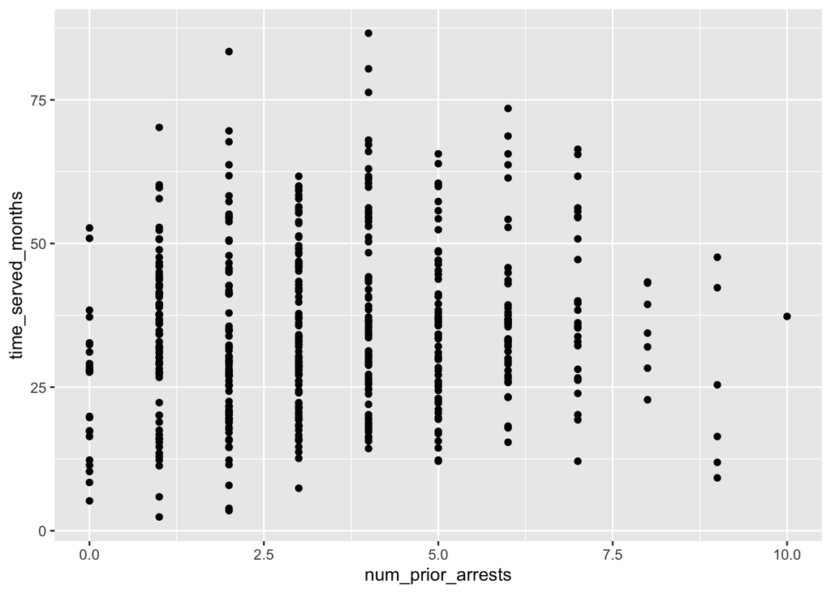

```r
dat %>%
  ggplot(aes(x = num_prior_arrests, y = time_served_months)) +
  geom_point()
```

Describe the relationship. Is it positive or negative? Does it look approximately linear?

**Answer:** There is a weak positive relationship: people with more prior arrests tend to have somewhat higher time served. The relationship is approximately linear, but there is a lot of variation around the general trend.

## Question 2

Fit a linear regression where you regress time served onto number of prior arrests.

```r
model <- lm(time_served_months ~ num_prior_arrests, data = dat)

summary(model)
```

```
##
## Call:
## lm(formula = time_served_months ~ num_prior_arrests, data = dat)
##
## Residuals:
##     Min      1Q  Median      3Q     Max
## -30.392 -10.715  -1.925   8.941  51.325
##
## Coefficients:
##                   Estimate Std. Error t value Pr(>|t|)
## (Intercept)        31.8202     1.2886  24.694   <2e-16 ***
## num_prior_arrests   0.8636     0.3238   2.667   0.0079 **
## ---
## Signif. codes:  0 '***' 0.001 '**' 0.01 '*' 0.05 '.' 0.1 ' ' 1
##
## Residual standard error: 14.58 on 498 degrees of freedom
## Multiple R-squared:  0.01408,    Adjusted R-squared:  0.0121
## F-statistic: 7.113 on 1 and 498 DF,  p-value: 0.007903
```

Which variable is the outcome/dependent variable?

**Answer:** `time_served_months`

Which variable is the explanatory/independent variable?

**Answer:** `num_prior_arrests`

## Question 3

Use the regression output to write the regression equation.

Predicted time served = 31.82 + 0.86 × number of prior arrests

Interpret the slope in words.

**Answer:** For each additional prior arrest, predicted time served increases by about 0.86 months, on average.

## Question 4

Add the regression line to the scatterplot.

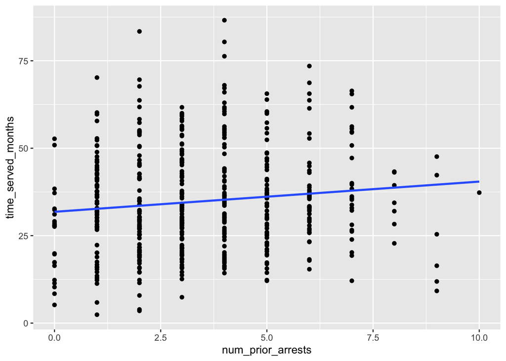

```r
dat %>%
  ggplot(aes(x = num_prior_arrests, y = time_served_months)) +
  geom_point() +
  geom_smooth(method = "lm", se = FALSE)
```

Does the regression line seem like a reasonable summary of the relationship?

**Answer:** It captures the slight positive trend in the data, but the observations are widely scattered around the line. So the line is a reasonable summary of the average trend, but number of prior arrests alone does not explain very much of the variation in time served.

## Question 5

Use the model to predict time served for a person with 5 prior arrests.

```r
predict(model,
        newdata = data.frame(num_prior_arrests = 5))
```

```
##        1
## 36.13811
```

Predicted time served = **36.14 months**

## Question 6

Look at the R-squared value in the regression output.

```r
summary(model)
```

```
##
## Call:
## lm(formula = time_served_months ~ num_prior_arrests, data = dat)
##
## Residuals:
##     Min      1Q  Median      3Q     Max
## -30.392 -10.715  -1.925   8.941  51.325
##
## Coefficients:
##                   Estimate Std. Error t value Pr(>|t|)
## (Intercept)        31.8202     1.2886  24.694   <2e-16 ***
## num_prior_arrests   0.8636     0.3238   2.667   0.0079 **
## ---
## Signif. codes:  0 '***' 0.001 '**' 0.01 '*' 0.05 '.' 0.1 ' ' 1
##
## Residual standard error: 14.58 on 498 degrees of freedom
## Multiple R-squared:  0.01408,    Adjusted R-squared:  0.0121
## F-statistic: 7.113 on 1 and 498 DF,  p-value: 0.007903
```

R-squared = **0.014**

Interpret the R-squared in words.

**Answer:** About 1.4% of the variation in time served is explained by its linear relationship with number of prior arrests. This is a very small proportion, so prior arrests alone are not a strong predictor of time served in this dataset.

Can we conclude that having more prior arrests **causes** a person to serve more time? Why or why not?

**Answer:** No. This regression shows an association between prior arrests and time served, not a causal effect. Other factors, such as offense type or seriousness, could be related to both prior arrests and time served. Establishing causation would require an appropriate research design, not just a regression.

## Question 6

Now let’s look at the income.data.csv dataset. - Load the data - Draw the scatterplot (without a line of best fit) (2 points) - Describe the scatterplot, calculate correlation if appropriate (5 points) - Fit a linear model and report the estimated i) slope, y-intercept, and iii) p-value for the slope. (5 points) - Test the assumptions of linear regression and assess the goodness of fit. (5 points)

```r
income_dat <- read_csv("/Users/mariacuellar/Github/crim_data_analysis/data/income_2.csv")
income_dat %>% summarise(cor=cor(income,happiness))
```

```
## # A tibble: 1 × 1
##     cor
##   <dbl>
## 1 0.823
```

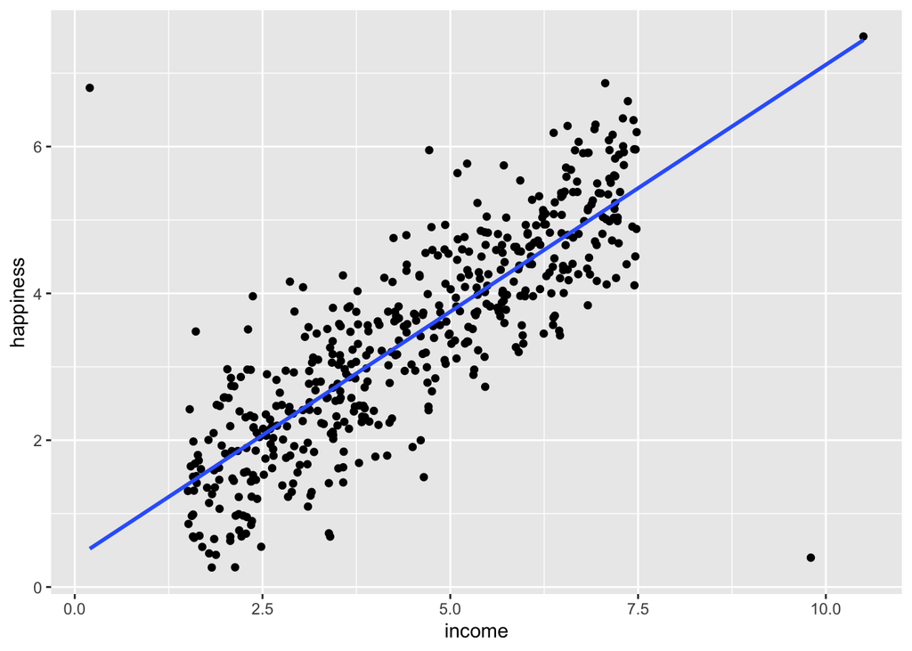

```r
income_dat %>%
  ggplot(aes(x = income, y = happiness)) +
  geom_point() +
  geom_smooth(method = "lm", se = FALSE)
```

```r
model <- lm(happiness~income, data=income_dat)

summary(model)
```

```
##
## Call:
## lm(formula = happiness ~ income, data = income_dat)
##
## Residuals:
##     Min      1Q  Median      3Q     Max
## -6.5803 -0.4967  0.0089  0.4709  6.2783
##
## Coefficients:
##             Estimate Std. Error t value Pr(>|t|)
## (Intercept)  0.38711    0.10015   3.865 0.000126 ***
## income       0.67278    0.02078  32.384  < 2e-16 ***
## ---
## Signif. codes:  0 '***' 0.001 '**' 0.01 '*' 0.05 '.' 0.1 ' ' 1
##
## Residual standard error: 0.8267 on 499 degrees of freedom
## Multiple R-squared:  0.6776, Adjusted R-squared:  0.6769
## F-statistic:  1049 on 1 and 499 DF,  p-value: < 2.2e-16
```

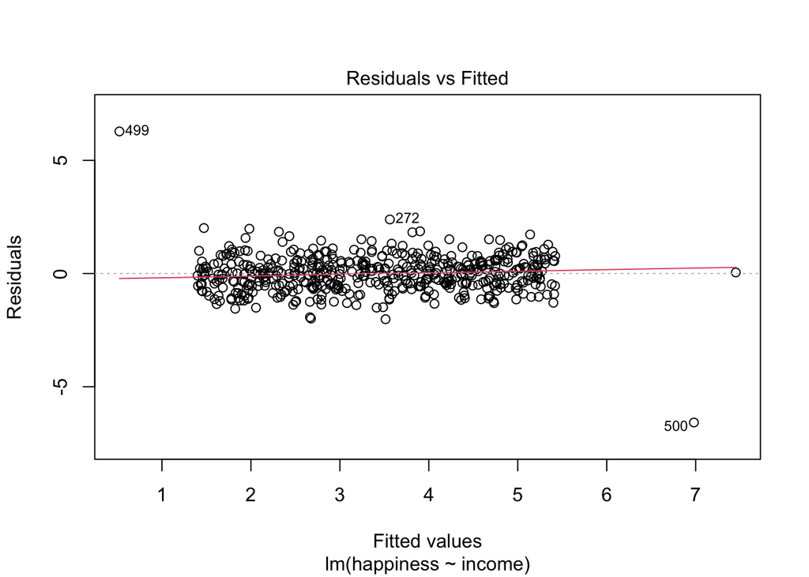

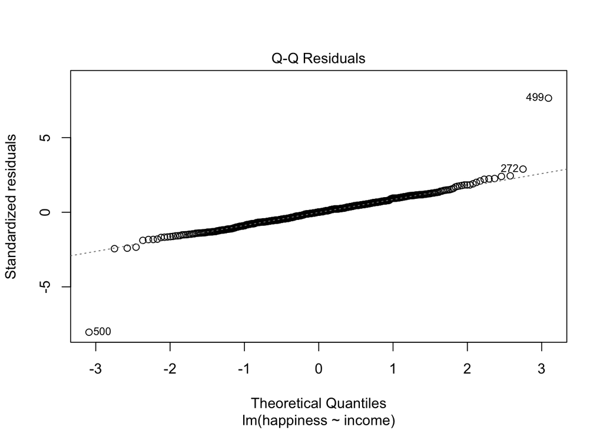

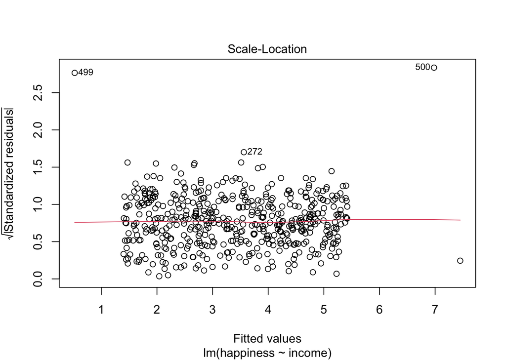

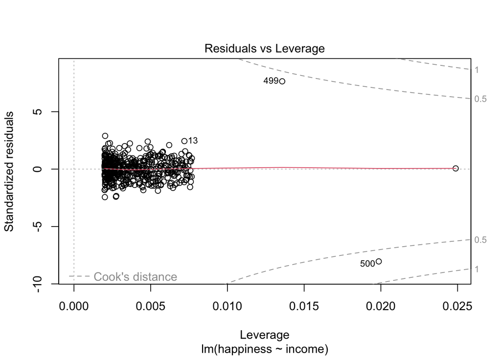

```r
plot(model)
```